#Assignment 2

##Setting up the workspace

I initially installed tidyverse and ggplot2 libraries.

```r
library(tidyverse)
```

```r
library(ggplot2)
library(viridis)
library(ggthemes)
library(wesanderson)
```

I loaded the data I created for the last assignment, that aim to explore the relationship between citizenship, class and race.

```r
citizenship_data <- read_csv("Citizenship-class-race.csv")
attach(citizenship_data)
```

Fret not if you can’t remember the variables. That’s why I formatted them on this nice table:

| Name | Code | Type |
| --- | --- | --- |
| Age | AGEP | cont |
| Citizenship Status | CIT | cat |
| Race | RACEAIN, RACASN, RACBLK, RACSOR, RACWHT | cat |
| Employment | ESR | cat |
| Education | SCHL | cat |
| Income | WAGP | cont |
| Year of Entry | YOEP | cont |
| Year of naturalization | CITWP | cont |

##Visualizing the distribution of continuous variables

```r
age_summary <- summary(AGEP)
age_sd <- sd(AGEP, na.rm = TRUE)
age_pop_mean_int <- t.test(AGEP)
income_summary <- summary(WAGP)
income_sd <- sd(WAGP, na.rm = TRUE)
income_pop_mean_int <- t.test(WAGP)
year_entry_summary <- summary(YOEP)
year_entry_sd <- sd(YOEP, na.rm = TRUE)
year_entry_pop_mean_int <- t.test(YOEP)
periodnat_summary <- summary(years_to_nat)
periodnat_sd <- sd(years_to_nat, na.rm = TRUE)
periodnat_pop_mean_int <- t.test(years_to_nat)
```

I’ll format my findings in a pleasant table.

```r
summary_table <- tibble(Statistic = c("Sample mean",
                "Median",
                "Standard deviation",
                "Interquartile range",
                "Population mean (95% confidence)"),
  `Median age (years)` = c(prettyNum(age_summary["Mean"], digits=3),
                           age_summary["Median"],
                           prettyNum(age_sd, digits = 3),
                           paste(age_summary["1st Qu."],"to",
                                 age_summary["3rd Qu."]),
                           paste(prettyNum(age_pop_mean_int$conf.int[1],
                                           digits=3), "to",
                                 prettyNum(age_pop_mean_int$conf.int[2],
                                               digits=3))),
    `Income` = c(prettyNum(income_summary["Mean"], digits=3),
                           income_summary["Median"],
                           prettyNum(income_sd, digits = 3),
                           paste(income_summary["1st Qu."],"to",
                                 income_summary["3rd Qu."]),
                           paste(prettyNum(income_pop_mean_int$conf.int[1],
                                           digits=3), "to",
                                 prettyNum(income_pop_mean_int$conf.int[2],
                                               digits=3))))
knitr::kable(summary_table,
             caption = "Summary")
```

Summary

| Statistic | Median age (years) | Income |
| --- | --- | --- |
| Sample mean | 55.6 | 38504 |
| Median | 56 | 13500 |
| Standard deviation | 15.5 | 66922 |
| Interquartile range | 45 to 66 | 0 to 52000 |
| Population mean (95% confidence) | 55.3 to 55.9 | 37073 to 39935 |

##Histograms

I will use ggplot2 to create a histogram for the distribution. The color selection is inspired by Vardas “Uncle Yanco”.

###Age

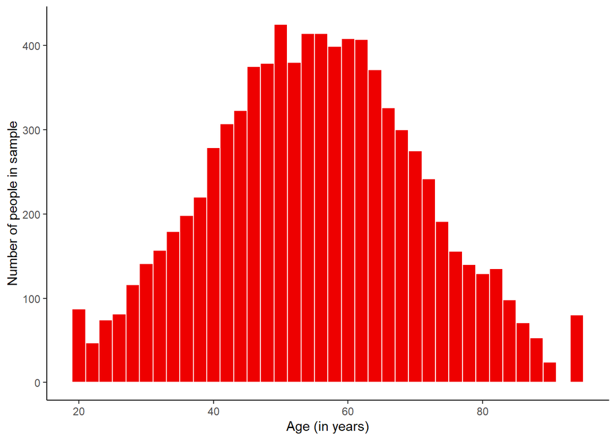

```r
ggplot(citizenship_data, aes(x = AGEP)) +
  geom_histogram(color = "white", binwidth = 2, fill = "red 2") +
  theme_classic() +
  scale_x_continuous(name = "Age (in years)") +
  scale_y_continuous(name = "Number of people in sample")
```

###Income

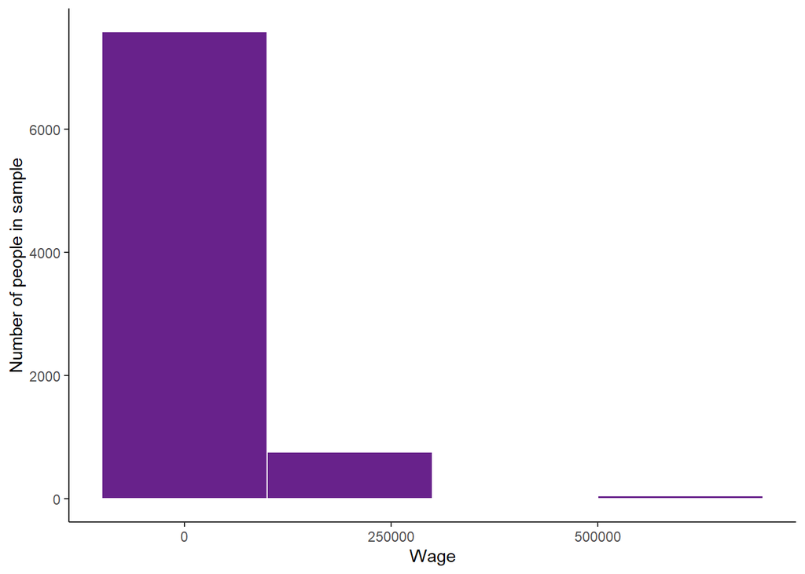

```r
ggplot(citizenship_data, aes(x = WAGP)) +
  geom_histogram(color = "white", binwidth = 200000, fill = "darkorchid4") +
  theme_classic() +
  scale_x_continuous(name = "Wage") +
  scale_y_continuous(name = "Number of people in sample")
```

###Period of naturalization

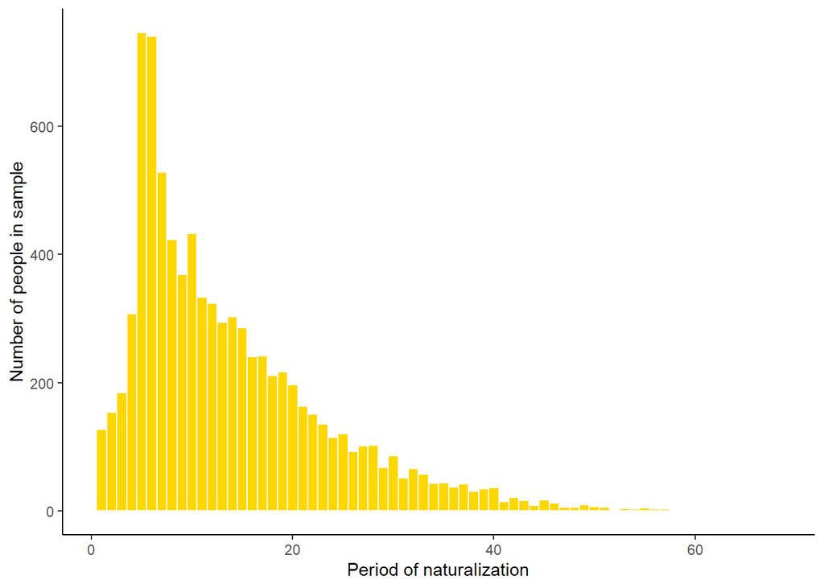

```r
ggplot(citizenship_data, aes(x = years_to_nat)) +
  geom_histogram(color = "white", binwidth = 1, fill = "gold1") +
  theme_classic() +
  scale_x_continuous(name = "Period of naturalization") +
  scale_y_continuous(name = "Number of people in sample")
```

```r
summary(years_to_nat)
```

```
##    Min. 1st Qu.  Median    Mean 3rd Qu.    Max.
##     1.0     6.0    11.0    13.8    19.0    68.0
```

```r
paste("The sample mean for period of naturalization is",
      prettyNum(mean(years_to_nat), digits = 0), "years.")
```

```
## [1] "The sample mean for period of naturalization is 14 years."
```

```r
paste("The sample median for period of naturalization is",
      prettyNum(median(years_to_nat), digits = 0,), "years.")
```

```
## [1] "The sample median for period of naturalization is 11 years."
```

```r
paste("The sample standard deviation for period of naturalization is",
      prettyNum(sd(years_to_nat), digits = 0), "years")
```

```
## [1] "The sample standard deviation for period of naturalization is 10 years"
```

```r
paste("The sample interquartile range for period of naturalization is",
      quantile(years_to_nat)["25%"], "to", quantile(years_to_nat)["75%"], "years.")
```

```
## [1] "The sample interquartile range for period of naturalization is 6 to 19 years."
```

What about the t.test?

```r
pop_mean <- t.test(years_to_nat)
pop_mean
```

```
##
##  One Sample t-test
##
## data:  years_to_nat
## t = 129.75, df = 8400, p-value < 2.2e-16
## alternative hypothesis: true mean is not equal to 0
## 95 percent confidence interval:
##  13.59458 14.01166
## sample estimates:
## mean of x
##  13.80312
```

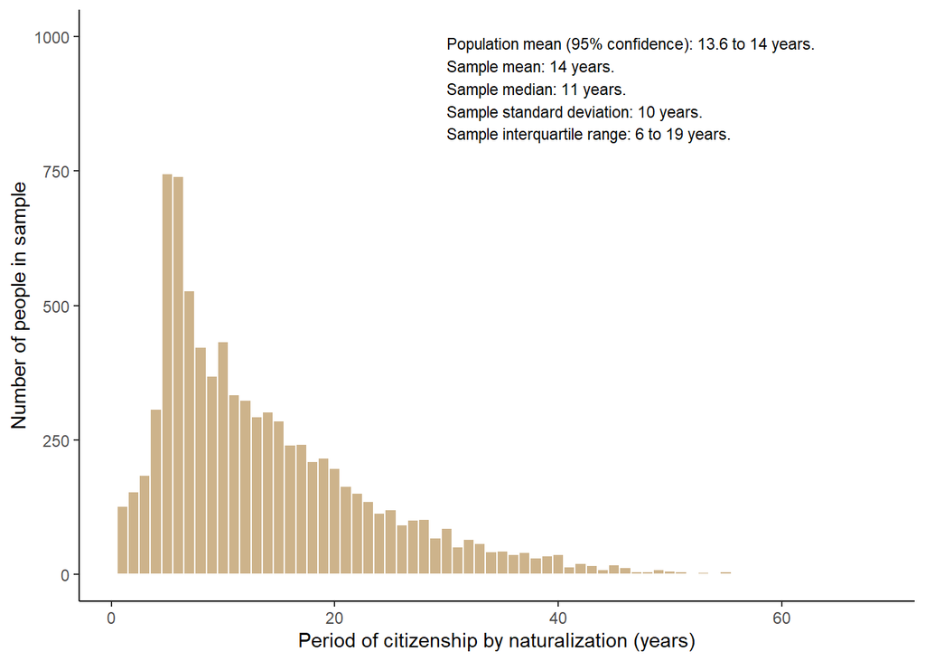

```r
hist <- ggplot(citizenship_data, aes(x = years_to_nat)) +
  geom_histogram(
    binwidth = 1
  )

hist +
  theme_classic() +
  scale_x_continuous(name = "Period of citizenship by naturalization (years)") +
  scale_y_continuous(name = "Number of people in sample") +
  geom_histogram(color = "white", binwidth = 1, fill = "navajowhite3") +
  annotate("text", x = 30, y = 1000, size = 3,
           label = paste("Population mean (95% confidence):",
                         prettyNum(pop_mean$conf.int[1], digits = 3),
                         "to",
                         prettyNum(pop_mean$conf.int[2], digits = 3),
                         "years.",
                         "\nSample mean:",
                         prettyNum(mean(years_to_nat), digits = 0), "years.",
                         "\nSample median:",
                         prettyNum(median(years_to_nat), digits = 0), "years.",
                         "\nSample standard deviation:",
                         prettyNum(sd(years_to_nat), digits = 0), "years.",
                         "\nSample interquartile range:",
                         prettyNum(quantile(years_to_nat)["25%"], digits = 0),
                         "to",
                         prettyNum(quantile(years_to_nat)["75%"], digits = 0),
                         "years."),
           hjust = 0, vjust = 1)
```

##Visualizing the distribution of categorical variables

###Employment

Let’s calculate the shares for each of the categories of employment.

```r
employment <- unique(ESR_label)
employment
```

```
## [1] "Not in labor force"
## [2] "Civilian employed, at work"
## [3] "Armed forces, at work"
## [4] "Unemployed"
## [5] "Civilian employed, with a job but not at work"
```

```r
not_in_labor_force <- t.test(ESR_label == employment [1])
civ_empl_work <- t.test(ESR_label == employment [2])
armed_forces_work <- t.test(ESR_label == employment [3])
unemployed <- t.test(ESR_label == employment [4])
civ_empl_not_work <- t.test(ESR_label == employment [5])

shares_employment <- tibble(Employment = c("Not in labor force",
                            "Civilian employed, at work",
                            "Armed forces, at work",
                            "Unemployed",
                            "Civilian employed, but not at work"),
                 `Share` = c(not_in_labor_force$estimate,
                             civ_empl_work$estimate,
                             armed_forces_work$estimate,
                             unemployed$estimate,
                             civ_empl_not_work$estimate),
                 Low = c(not_in_labor_force$conf.int[1],
                         civ_empl_work$conf.int[1],
                          armed_forces_work$conf.int[1],
                         unemployed$conf.int[1],
                         civ_empl_not_work$conf.int[1]),
                 High = c(not_in_labor_force$conf.int[2],
                         civ_empl_work$conf.int[2],
                          armed_forces_work$conf.int[2],
                         unemployed$conf.int[2],
                         civ_empl_not_work$conf.int[2]))
shares_employment
```

```
## # A tibble: 5 x 4
##   Employment                           Share      Low    High
##   <chr>                                <dbl>    <dbl>   <dbl>
## 1 Not in labor force                 0.385   0.375    0.395
## 2 Civilian employed, at work         0.576   0.565    0.586
## 3 Armed forces, at work              0.00131 0.000536 0.00208
## 4 Unemployed                         0.0213  0.0182   0.0244
## 5 Civilian employed, but not at work 0.0169  0.0141   0.0197
```

I will visualize these results with a bar chart.

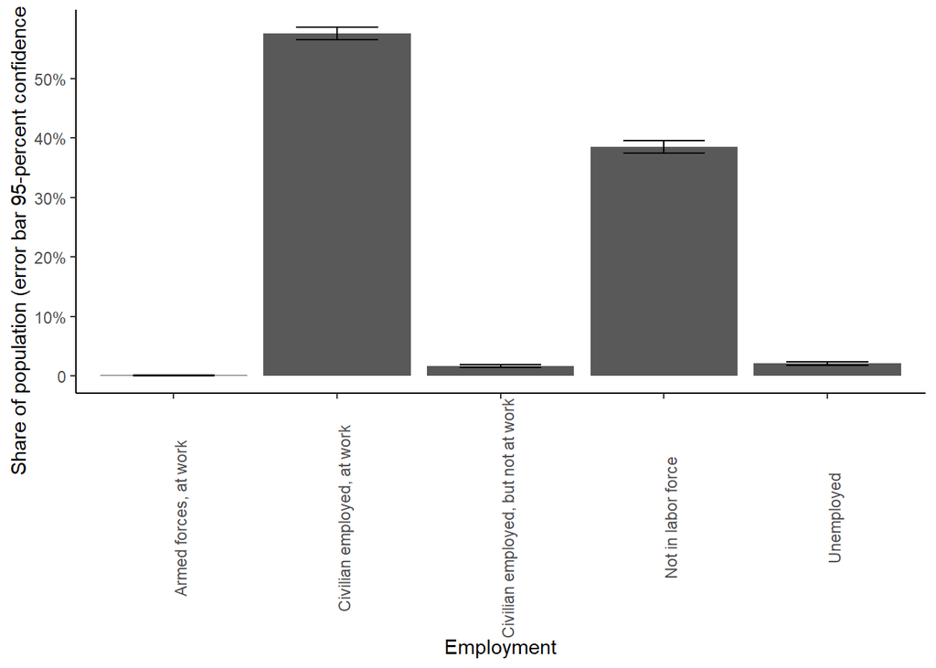

```r
ggplot(shares_employment, aes(x = Employment, y = Share, ymin = Low, ymax = High)) +
  geom_bar(stat = "identity") +
  geom_errorbar(width = 0.5) +
  theme_classic() +
   theme(axis.text.x = element_text(angle = 90)) +
  scale_y_continuous(name = "Share of population (error bar 95-percent confidence interval)",
                     breaks = c(0, 0.1, 0.2, 0.3, 0.4, 0.5),
                     labels = c("0", "10%", "20%", "30%", "40%", "50%"))
```

###Level of education

```r
education <- unique(SCHL_label)
education
```

```
##  [1] "No schooling completed"
##  [2] "Some college, but less than 1 year"
##  [3] "Grade 11"
##  [4] "Grade 3"
##  [5] "Regular high school diploma"
##  [6] "Associate's degree"
##  [7] "Grade 9"
##  [8] "1 or more years of college credit, no degree"
##  [9] "GED or alternative credential"
## [10] "Master's degree"
## [11] "12th grade - no diploma"
## [12] "Grade 7"
## [13] "Grade 10"
## [14] "Grade 6"
## [15] "Bachelor's degree"
## [16] "Grade 5"
## [17] "Kindergarten"
## [18] "Grade 1"
## [19] "Professional degree beyond a bachelor's degree"
## [20] "Doctorate degree"
## [21] "Grade 8"
## [22] "Grade 4"
## [23] "Grade 2"
## [24] "Nursery school, preschool"
```

```r
no_schooling <- t.test(SCHL_label == education [1])
some_college <- t.test(SCHL_label == education [2])
high_school <- t.test(SCHL_label == education [5])
associate_degree <- t.test(SCHL_label == education [6])
college_1 <- t.test(SCHL_label == education [8])
ged <- t.test(SCHL_label == education [9])
masters <- t.test(SCHL_label == education [10])
bachelors <- t.test(SCHL_label == education [15])
prof_degree <- t.test(SCHL_label == education [19])
doctorate <- t.test(SCHL_label == education [20])

shares_education <- tibble(Education = c("No schooling",
                            "Some college, but less than 1 year",
                            "Regular high school diploma",
                            "Associate's degree",
                            "1 or more years of college credit, no degree",
                            "GED",
                            "Master's degree",
                            "Bachelor's degree",
                            "Professional degree beyond a bachelor's degree",
                            "Doctorate degree"),
                 `Share` = c(no_schooling$estimate,
                             some_college$estimate,
                             high_school$estimate,
                             associate_degree$estimate,
                             college_1$estimate,
                             ged$estimate,
                             masters$estimate,
                             bachelors$estimate,
                             prof_degree$estimate,
                             doctorate$estimate),
                 Low = c(no_schooling$conf.int[1],
                         some_college$conf.int[1],
                          high_school$conf.int[1],
                         associate_degree$conf.int[1],
                         college_1$conf.int[1],
                         ged$conf.int[1],
                         masters$conf.int[1],
                         bachelors$conf.int[1],
                         prof_degree$conf.int[1],
                         doctorate$conf.int[1]),
                 High = no_schooling$conf.int[2],
                         some_college$conf.int[2],
                          high_school$conf.int[2],
                         associate_degree$conf.int[2],
                         college_1$conf.int[2],
                         ged$conf.int[2],
                         masters$conf.int[2],
                         bachelors$conf.int[2],
                         prof_degree$conf.int[2],
                         doctorate$conf.int[2])
shares_education
```

```
## # A tibble: 10 x 13
##    Education  Share    Low   High `some_college$c~ `high_school$co~
##    <chr>      <dbl>  <dbl>  <dbl>            <dbl>            <dbl>
##  1 No schoo~ 0.0579 0.0529 0.0628           0.0509            0.162
##  2 Some col~ 0.0464 0.0419 0.0628           0.0509            0.162
##  3 Regular ~ 0.154  0.146  0.0628           0.0509            0.162
##  4 Associat~ 0.0823 0.0764 0.0628           0.0509            0.162
##  5 1 or mor~ 0.118  0.111  0.0628           0.0509            0.162
##  6 GED       0.0213 0.0182 0.0628           0.0509            0.162
##  7 Master's~ 0.0894 0.0833 0.0628           0.0509            0.162
##  8 Bachelor~ 0.219  0.211  0.0628           0.0509            0.162
##  9 Professi~ 0.0245 0.0212 0.0628           0.0509            0.162
## 10 Doctorat~ 0.0237 0.0204 0.0628           0.0509            0.162
## # ... with 7 more variables: `associate_degree$conf.int[2]` <dbl>,
## #   `college_1$conf.int[2]` <dbl>, `ged$conf.int[2]` <dbl>,
## #   `masters$conf.int[2]` <dbl>, `bachelors$conf.int[2]` <dbl>,
## #   `prof_degree$conf.int[2]` <dbl>, `doctorate$conf.int[2]` <dbl>
```

I will visualize these results with a bar chart.

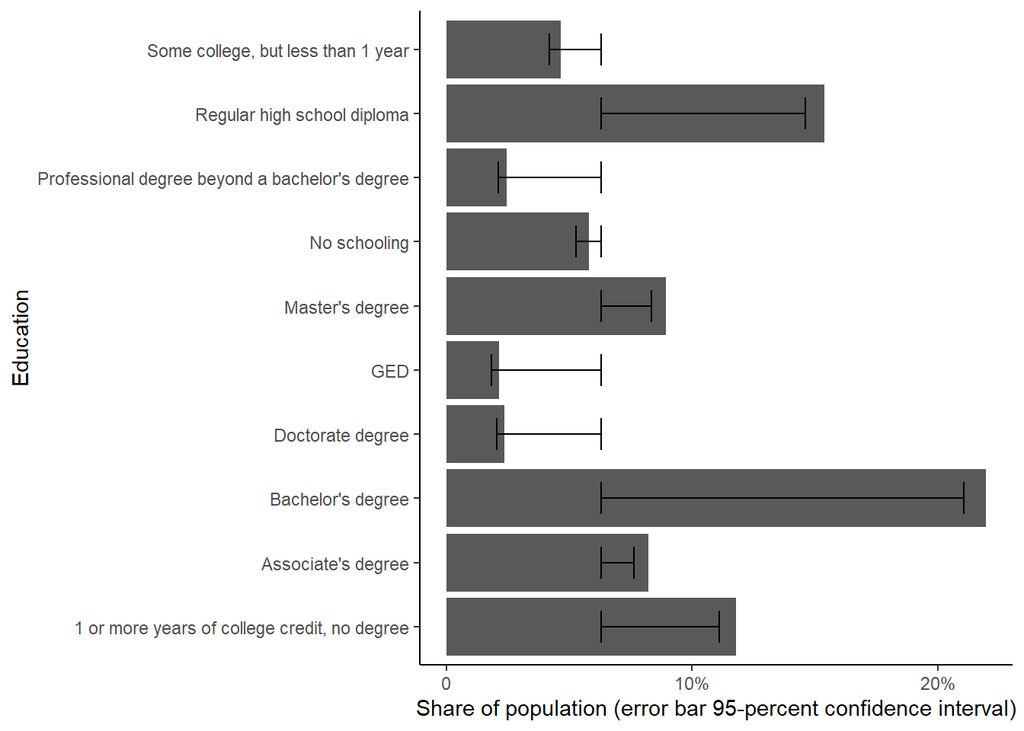

```r
ggplot(shares_education, aes(x = Education, y = Share, ymin = Low, ymax = High)) +
  geom_bar(stat = "identity") +
  geom_errorbar(width = 0.5) +
  theme_classic() +
  scale_y_continuous(name = "Share of population (error bar 95-percent confidence interval)",
                     breaks = c(0, 0.1, 0.2, 0.3, 0.4, 0.5),
                     labels = c("0", "10%", "20%", "30%", "40%", "50%")) +
  coord_flip()
```